# Project 4 - Explore and Summarize Data

To start with, I am an ardent football fan with most of my free time spent either playing football or watching football. If not this, then I play PC football game - FIFA.

Therefore, I have decided to use FIFA15 data as my working data.

**About the dataset**

- Number of observations - 12,236
- Number of Variables - 60
- *Variables description are as follows*
- $ Club.Name
- $ Nation
- $ League
- $ SearchName = Player name
- $ position = playing position
- $ Rating = FIFA rating (out of 100)
- $ Category
- $ Skill = skill rating
- **next few variables are to measure skillsets**
- $ awr
- $ dwr
- $ PreferredFoot
- $ weakfoot
- $ Height
- $ CommonName
- $ statsid
- $ Position
- $ Rare
- $ Attr1
- $ Acceleration
- $ SprintSpeed
- $ Attr2
- $ Positioning
- $ Finishing
- $ ShotPower
- $ LongShot
- $ Volleys
- $ Penalties
- $ Attr3
- $ TactAware
- $ Vision
- $ ShortPass
- $ LongPass
- $ Curve
- $ Crossing
- $ FKAcc
- $ Attr4
- $ BallControl
- $ Dribbling
- $ Balance
- $ Agility
- $ Reactions
- $ Attr5
- $ Marking
- $ Interceptions
- $ StandingTackle
- $ SlideTackle
- $ HeadingAcc
- $ Attr6
- $ Strength
- $ Jumping
- $ Aggression
- $ Stamina
- $ Potential
- $ GKDiving
- $ GKHandling
- $ GKKicking
- $ GKPositioning
- $ GKReflexes
- $ playerID
- $ statsid.1

**Univariate Exploration**

Let's set the working directory and import our dataset.

```r
#Setting working directory
setwd("/Users/madua/Desktop")
#Fetching the data
fifa <- read.csv("fifa15.csv")

str(fifa)
```

```
## 'data.frame':    12236 obs. of  60 variables:
##  $ Club.Name     : Factor w/ 579 levels "1. FC Heidenheim",..: 306 357 16 160 560 561 281 515 494 83 ...
##  $ Nation        : Factor w/ 144 levels "Albania","Algeria",..: 58 138 50 112 43 43 112 92 112 101 ...
##  $ League        : Factor w/ 38 levels "Abdul Latif Jameel League",..: 23 23 21 27 4 4 29 17 27 12 ...
##  $ SearchName    : Factor w/ 11999 levels "A.J. DeLaGarza",..: 1 2 4 5 6 7 8 9 10 11 ...
##  $ position      : Factor w/ 17 levels "CAM","CB","CDM",..: 2 2 3 7 1 7 14 2 17 2 ...
##  $ Rating        : int  68 63 60 55 56 73 68 67 57 72 ...
##  $ Category      : Factor w/ 3 levels "MOTM","Regular",..: 2 2 2 2 2 3 2 2 2 2 ...
##  $ Skill         : int  2 2 2 2 2 2 3 2 3 2 ...
##  $ awr           : int  2 2 2 2 2 2 2 2 2 2 ...
##  $ dwr           : int  3 2 2 2 2 2 2 2 2 2 ...
##  $ PreferredFoot : Factor w/ 2 levels "Left","Right": 2 2 2 2 2 1 2 2 1 2 ...
##  $ weakfoot      : int  3 3 3 4 3 3 4 3 2 3 ...
##  $ Height        : int  175 183 176 181 173 170 170 184 180 183 ...
##  $ CommonName    : Factor w/ 1526 levels "","Aar\321n",..: 1 1 1 1 1 1 1 1 1 1 ...
```

[output cut: 46 more lines]

```r
summary(fifa)
```

```
##                   Club.Name           Nation
##  Arsenal               :   35   England  :1265
##  Crystal Palace        :   34   France   : 785
##  FC Schalke 04         :   34   Spain    : 709
##  West Ham United       :   34   Germany  : 658
##  Everton               :   33   Italy    : 480
##  Jeonbuk Hyundai Motors:   33   Argentina: 403
##  (Other)               :12033   (Other)  :7936
##                           League                SearchName
##  Football League Championship: 664   Rafinha         :    5
##  Barclays Premier League     : 627   Alvaro~<8d>lvaro:    4
##  TIM Serie A                 : 546   Felipe          :    4
##  Bundesliga                  : 528   Juan Carlos     :    4
##  Ligue 1                     : 519   Leonardo        :    4
##  Liga BBVA                   : 481   Alan            :    3
##  (Other)                     :8871   (Other)         :12212
##     position        Rating         Category         Skill
##  CB     :2080   Min.   :40.00   MOTM   :    2   Min.   :1.000
##  ST     :1775   1st Qu.:61.00   Regular:12042   1st Qu.:2.000
##  CM     :1450   Median :65.00   TOTW   :  192   Median :2.000
##  GK     :1311   Mean   :65.26                   Mean   :2.299
##  CDM    : 945   3rd Qu.:70.00                   3rd Qu.:3.000
##  RB     : 929   Max.   :95.00                   Max.   :5.000
##  (Other):3746
##       awr             dwr       PreferredFoot    weakfoot
##  Min.   :1.000   Min.   :1.00   Left :2840    Min.   :1.000
##  1st Qu.:2.000   1st Qu.:2.00   Right:9396    1st Qu.:3.000
##  Median :2.000   Median :2.00                 Median :3.000
##  Mean   :2.184   Mean   :2.05                 Mean   :2.979
##  3rd Qu.:2.000   3rd Qu.:2.00                 3rd Qu.:3.000
##  Max.   :3.000   Max.   :3.00                 Max.   :5.000
##
##      Height            CommonName       statsid            Position
##  Min.   :155.0              :10596   Min.   :       2   CB     :2080
##  1st Qu.:177.0   Rafinha    :    5   1st Qu.:  173207   ST     :1775
##  Median :182.0   Felipe     :    4   Median :  194912   CM     :1450
##  Mean   :181.4   Juan Carlos:    4   Mean   : 2068329   GK     :1311
##  3rd Qu.:186.0   Leonardo   :    4   3rd Qu.:  210263   CDM    : 945
##  Max.   :204.0   <8d>lvaro  :    4   Max.   :67303629   RB     : 929
##                  (Other)    : 1619                      (Other):3746
```

[output cut: 73 more lines]

```
##  Min.   :40.00   Min.   : 1.00   Min.   : 1.00   Min.   : 1.00
##  1st Qu.:65.00   1st Qu.: 7.00   1st Qu.: 8.00   1st Qu.: 8.00
##  Median :69.00   Median :11.00   Median :11.00   Median :11.00
##  Mean   :69.26   Mean   :15.85   Mean   :15.51   Mean   :15.35
##  3rd Qu.:74.00   3rd Qu.:13.00   3rd Qu.:14.00   3rd Qu.:14.00
##  Max.   :95.00   Max.   :88.00   Max.   :87.00   Max.   :92.00
##
##  GKPositioning     GKReflexes       playerID        statsid.1
##  Min.   : 1.00   Min.   : 1.00   Min.   :     2   Min.   :       2
##  1st Qu.: 8.00   1st Qu.: 8.00   1st Qu.:172098   1st Qu.:  173207
##  Median :10.00   Median :10.00   Median :193274   Median :  194912
##  Mean   :15.51   Mean   :16.01   Mean   :183017   Mean   : 2068329
##  3rd Qu.:13.00   3rd Qu.:13.00   3rd Qu.:208788   3rd Qu.:  210263
##  Max.   :90.00   Max.   :90.00   Max.   :225205   Max.   :67303629
##
```

As depicted by structure of this dataset, we have both categorical and numeric variables. Therefore there is no need to add extra categorical variable

Let's find if there are any duplicates in our dataset

```r
#Finding duplicates
duplicates <- duplicated(fifa$SearchName)
duplicate_players <- fifa[duplicates==TRUE,]
duplicate_players$SearchName
```

```
##   [1] Cristiano Ronaldo
##   [2] Abdulrahman Al Ghamdi
##   [3] Abraham
##   [4] Adam Smith
##   [5] Benat~Be\320at
##   [6] Aitor
##   [7] Albert Riera
##   [8] Alberto
##   [9] Arjen Robben
##  [10] Alejandro Castro
##  [11] Alex
##  [12] Alex
##  [13] Angel Di Maria~\215ngel Di Mar\325a
##  [14] Carlos Tevez~Carlos T_vez
##  [15] Alvaro~\215lvaro
```

[output cut: 223 more lines]

Let's see position wise distribution of duplicate players

```r
table(duplicate_players$position)
```

```
##
## CAM  CB CDM  CF  CM  GK  LB  LF  LM  LW LWB  RB  RF  RM  RW RWB  ST
##  29  39  20   3  16  20  10   0  19  10   0  13   0  22  10   0  26
```

In football, its common that we have same players playing on different positions, depending on tactics. We can use below mentioned code to establish this fact

```r
realduplicates <- duplicated(fifa$playerID)
realduplicate_players <- fifa[realduplicates==TRUE,]
realduplicate_players$SearchName
```

```
##  [1] Cristiano Ronaldo
##  [2] Benat~Be\320at
##  [3] Arjen Robben
##  [4] Angel Di Maria~\215ngel Di Mar\325a
##  [5] Carlos Tevez~Carlos T_vez
##  [6] Balazs Dzsudzsak~Bal\340zs Dzsudzs\340k
##  [7] Ivan Perisic~Ivan Peri_ic
##  [8] Arjen Robben
##  [9] Wesley Sneijder
## [10] Gylfi Sigur_sson
## [11] Ivan Rakitic~Ivan Rakitic
## [12] Xherdan Shaqiri
## [13] Victor Wanyama
## [14] Ivan Perisic~Ivan Peri_ic
## [15] Sofiane Feghouli
```

[output cut: 73 more lines]

Again distributing this position wise

```r
table(realduplicate_players$position)
```

```
##
## CAM  CB CDM  CF  CM  GK  LB  LF  LM  LW LWB  RB  RF  RM  RW RWB  ST
##  23   0   7   2   5   0   0   0  10   8   0   0   0  16   7   0   9
```

Verifying our hypothesis of multi-position players by using example of player named - Arjen Robben

```r
multipositions_players <- realduplicate_players
Robben <- multipositions_players[multipositions_players$SearchName == "Arjen Robben",]
table(Robben$position)
```

```
##
## CAM  CB CDM  CF  CM  GK  LB  LF  LM  LW LWB  RB  RF  RM  RW RWB  ST
##   0   0   0   0   0   0   0   0   0   0   0   0   0   1   1   0   0
```

This dataset has multiple leagues, so lets plot a barchart to see number of players belonging to different leagues

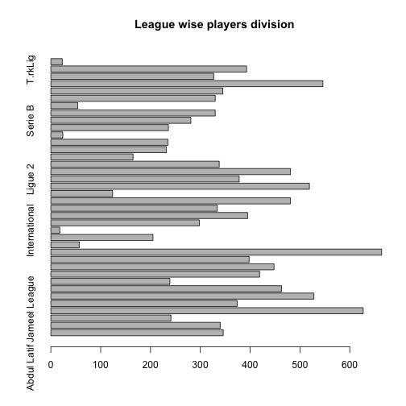

```r
plot(fifa$League,type="h",horiz=T, main = "League wise players division")
```

**Univariate Analysis**

**What is the structure of your dataset?**

There are 12,236 players in the dataset with 60 features (country, league, club, playing position, rating, skills etc).

**Other observations:**

**What is/are the main feature(s) of interest in your dataset?**

The main features in the data set are various skills of a player and his playing position. I???d like to determine which skills are important to predict a rating of a player. At the same time it is interesting to observe which league has attacking mindset or a defensive mindset

**Did you create any new variables from existing variables in the dataset?**

I created a variable - “Mindset” to evaluate players' intent whether he prefers attack or defence, basis his playing position

**Bivariate Plots**

Football is a sport of 11 players, which means there are atleast 11 different positions for any single player. Now I will create a new column called **“Mindset”** which represents mindset of a player basis his playing position i.e. **Attack** if he is playing in advanced position else **Defence**

```r
#creating mindset of players i.e. attack or defence
library(data.table)
DT <- data.table(fifa)
DT[,mindset := ifelse(position %in% c("CAM", "CF",  "CM", "LF",  "LM",  "LW", "RF",  "RM", "RW",  "ST"), "Attack", "Defence")]
```

```
##                      Club.Name              Nation                  League
##     1:               LA Galaxy                Guam     Major League Soccer
##     2:  New England Revolution       United States     Major League Soccer
##     3:            AS Monaco FC              France                 Ligue 1
##     4:              Derry City Republic of Ireland   SSE Airtricity League
##     5:    West Bromwich Albion             England Barclays Premier League
##    ---
## 12232: Elche Club de F\317tbol              Poland               Liga BBVA
## 12233:          Galatasaray SK              Turkey              T\331rkLig
## 12234:  Independiente Santa Fe            Colombia        Liga Postob\321n
## 12235:    En Avant de Guingamp             Senegal                 Ligue 1
## 12236:    En Avant de Guingamp             Senegal                 Ligue 1
##                                   SearchName position Rating Category
##     1:                        A.J. DeLaGarza       CB     68  Regular
##     2:                           A.J. Soares       CB     63  Regular
```

[output cut: 105 more lines]

```r
fifa <- DT
```

In this dataset we have multiple leagues, belonging to different countries. Let's narrow down our data to top 5 leagues of the world (which belongs to England, France, Germany, Italy and Spain)

```r
#Selecting top 5 leagues
library(dplyr)
Big5 <- c("Barclays Premier League","Ligue 1","Bundesliga","TIM Serie A","Liga BBVA" )
Topleagues <- filter(fifa, League %in% Big5)
str(Topleagues)
```

```
## Classes 'data.table' and 'data.frame':   2701 obs. of  61 variables:
##  $ Club.Name     : Factor w/ 579 levels "1. FC Heidenheim",..: 16 560 561 425 425 386 172 375 347 387 ...
##  $ Nation        : Factor w/ 144 levels "Albania","Algeria",..: 50 43 43 110 110 127 123 95 95 2 ...
##  $ League        : Factor w/ 38 levels "Abdul Latif Jameel League",..: 21 4 4 19 19 21 19 21 21 35 ...
##  $ SearchName    : Factor w/ 11999 levels "A.J. DeLaGarza",..: 4 6 7 2290 2290 11982 37 43 44 45 ...
##  $ position      : Factor w/ 17 levels "CAM","CB","CDM",..: 3 1 7 17 10 17 10 1 2 8 ...
##  $ Rating        : int  60 56 73 94 93 91 70 74 71 66 ...
##  $ Category      : Factor w/ 3 levels "MOTM","Regular",..: 2 2 3 3 3 3 2 2 2 2 ...
##  $ Skill         : int  2 2 2 5 5 4 3 3 2 3 ...
##  $ awr           : int  2 2 2 3 3 2 2 2 2 2 ...
##  $ dwr           : int  2 2 2 1 1 1 2 2 2 2 ...
##  $ PreferredFoot : Factor w/ 2 levels "Left","Right": 2 2 1 2 2 2 1 2 1 2 ...
##  $ weakfoot      : int  3 3 3 4 4 4 3 3 2 4 ...
##  $ Height        : int  176 173 170 185 185 195 170 179 180 183 ...
##  $ CommonName    : Factor w/ 1526 levels "","Aar\321n",..: 1 1 1 276 276 1 2 1 1 1 ...
```

[output cut: 48 more lines]

Let us plot mindset of the players belonging to these top 5 leagues. By doing this we will be able to understand that which nation's league plays more offensive football comparing to others.

```r
#visualizing mindset grouped by leagues
d <- data.frame(column1 = Topleagues$League, column2 = Topleagues$mindset, Ratings = Topleagues$Rating)
require(lattice)
```

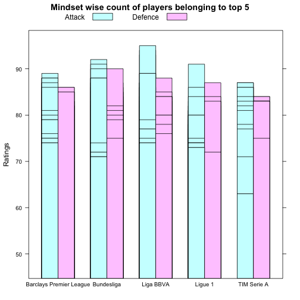

```r
barchart(Ratings ~ column1,groups = column2, d,auto.key = list(columns = 3),main = "Mindset wise count of players belonging to top 5")
```

We have data corresponding to prefferred foot of a player as well. I would like to take an opportunity to create a Mosaic plot for the players belonging to different positions

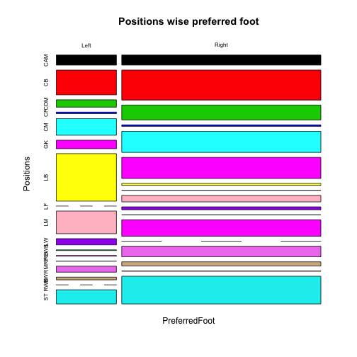

```r
#Position wise preferred foot
totals = table(fifa$PreferredFoot,fifa$position)

#creating custom palette
mypal <- c("black",   "red" ,    "green3" , "blue"   , "cyan"  ,  "magenta" ,"yellow"  ,"gray","pink", "purple", "springgreen", "magenta", "orange", "violet", "tan", "tomato", "cyan2", "thistle", "sienna", "plum4" )


#creating Mosaic plot
mosaicplot(totals,main="Positions wise preferred foot",xlab="PreferredFoot",ylab="Positions",color = mypal)
```

We had already seen players in various positions segmented by foot.

Now just to satiate the curiousity, whether right footed players are rare or left footed. So Let's take a look at rare players segmented by Preferred foot.

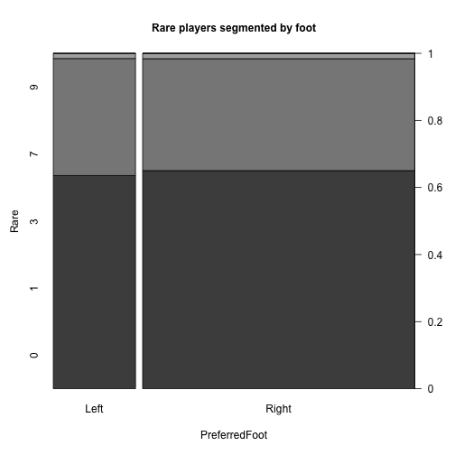

```r
#Rare players segmented by foot
library(vcd)
attach(fifa)
counts <- table(PreferredFoot,Rare)
spine(counts, main = "Rare players segmented by foot")
```

```r
#Segregating players based on their playing position
wingers <- fifa[fifa$position == c("LW","RW"),]
mid <- fifa[fifa$position == c("CM","LM","RM"),]
attacking_mid <- fifa[fifa$position == "CAM",]
defensive_mid <- fifa[fifa$position == "CDM",]
def <- fifa[fifa$position == c("CB","LB","RB","LWB","RWB"),]
gk <- fifa[fifa$position == "GK",]
striker <- fifa[fifa$position == c("ST","CF"),]
```

To establish relationship between striker and some of the main skills and league, I had plot following graph -

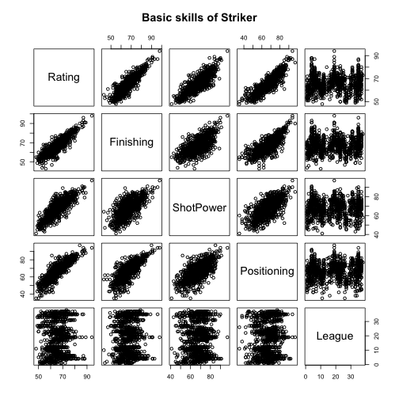

```r
pairs(~Rating + Finishing + ShotPower + Positioning + League, data = striker, main = "Basic skills of Striker")
```

Similarly smooth plot to confirm or deny whether strength is an important aspect for Defender

```
## Copyright M. P. Wand 1997-2009
```

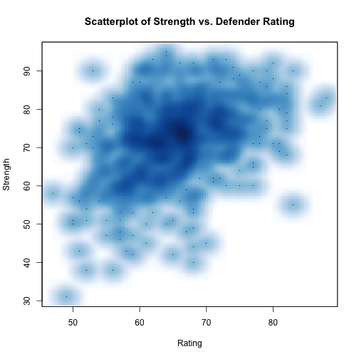

```r
#Smooth plot to relate strength and rating of a defender
with(def,smoothScatter(Rating, Strength , main="Scatterplot of Strength vs. Defender Rating"))
```

Before moving to multivariate segment, I would quicly like to explore few more datapoints such as corelation between certain fields and some more observations

```r
f <- fifa
#to find maximum rating within each league
aggregate(Rating~League, f, max)
```

```
##                                 League Rating
## 1            Abdul Latif Jameel League     78
## 2                          Allsvenskan     73
## 3                  Austrian Bundesliga     77
## 4              Barclays Premier League     89
## 5                   Belgium Pro League     76
## 6                           Bundesliga     92
## 7                         Bundesliga 2     76
## 8       Campeonato Nacional Scotiabank     76
## 9                           Eredivisie     79
## 10                   Football League 1     69
## 11                   Football League 2     66
## 12        Football League Championship     78
## 13                         Hellas Liga     78
## 14                    Hyundai A-League     80
```

[output cut: 24 more lines]

```r
#to find maximum rating within each league, segmented by position
aggregate(Rating~League + position, f, max)
```

```
##                                  League position Rating
## 1             Abdul Latif Jameel League      CAM     78
## 2                           Allsvenskan      CAM     69
## 3                   Austrian Bundesliga      CAM     70
## 4               Barclays Premier League      CAM     89
## 5                    Belgium Pro League      CAM     75
## 6                            Bundesliga      CAM     85
## 7                          Bundesliga 2      CAM     70
## 8        Campeonato Nacional Scotiabank      CAM     73
## 9                            Eredivisie      CAM     78
## 10                    Football League 1      CAM     69
## 11                    Football League 2      CAM     63
## 12         Football League Championship      CAM     75
## 13                          Hellas Liga      CAM     76
## 14                     Hyundai A-League      CAM     72
```

[output cut: 463 more lines]

There can be a possibility that player with good sprint speed can have a good rating. Let's establish corelation between these two parameters

```r
#corelation between Sprintspeed and rating
cor(f$SprintSpeed,f$Rating)
```

```
## [1] 0.2272479
```

As we can see, there is not much co-relation between the two factors. Guess it would take much more to be a good player thanjust a good speed Let's explore what it takes to be a good goalkeeper

```r
cor.test(gk$Rating,gk$GKHandling)
```

```
##
##  Pearson's product-moment correlation
##
## data:  gk$Rating and gk$GKHandling
## t = 79.5934, df = 1309, p-value < 2.2e-16
## alternative hypothesis: true correlation is not equal to 0
## 95 percent confidence interval:
##  0.9006091 0.9191965
## sample estimates:
##       cor
## 0.9103609
```

So as depicted by result, a good handling capability can make up a good goalkeeper

Following few commands are to create a table and have view of some of the parameters -

```r
table(f$League)
```

```
##
##           Abdul Latif Jameel League                         Allsvenskan
##                                 346                                 340
##                 Austrian Bundesliga             Barclays Premier League
##                                 241                                 627
##                  Belgium Pro League                          Bundesliga
##                                 374                                 528
##                        Bundesliga 2      Campeonato Nacional Scotiabank
##                                 463                                 239
##                          Eredivisie                   Football League 1
##                                 419                                 448
##                   Football League 2        Football League Championship
##                                 398                                 664
##                         Hellas Liga                    Hyundai A-League
##                                  57                                 205
##                       International                    K LEAGUE Classic
##                                  18                                 298
##                    LIGA Bancomer MX                       Liga Adelante
##                                 395                                 334
##                           Liga BBVA                    Liga Postob\321n
##                                 481                                 124
##                             Ligue 1                             Ligue 2
##                                 519                                 378
##                 Major League Soccer                       Primeira Liga
##                                 481                                 338
##                 Primera Divisi\321n             Raiffeisen Super League
##                                 165                                 232
##               SSE Airtricity League                     Scotland League
##                                 235                                  24
##                Scottish Premiership                             Serie B
##                                 236                                 281
## Sogaz Russian Football Championship                    South African FL
##                                 330                                  54
##                           Superliga                T-Mobile Ekstraklasa
##                                 330                                 345
##                         TIM Serie A                         Tippeligaen
##                                 546                                 327
##                          T\331rkLig                 Ukraine Wyscha Liga
##                                 393                                  23
```

```r
table(f$Nation,f$League)
```

```
##
##                            Abdul Latif Jameel League Allsvenskan
##   Albania                                          0           1
##   Algeria                                          1           0
##   Angola                                           0           0
##   Antigua and Barbuda                              0           0
##   Argentina                                        0           0
##   Armenia                                          0           0
##   Australia                                        0           0
##   Austria                                          0           0
##   Azerbaijan                                       0           0
##   Bahrain                                          1           0
##   Barbados                                         0           0
##   Belarus                                          0           0
##   Belgium                                          0           0
##   Benin                                            0           0
##   Bermuda                                          0           0
##   Bolivia                                          1           0
##   Bosnia and Herzegovina                           0           0
##   Brazil                                          10           9
##   Bulgaria                                         0           0
##   Burkina Faso                                     0           0
##   Burundi                                          0           0
##   Cambodia                                         0           0
##   Cameroon                                         2           1
##   Canada                                           0           1
##   Cape Verde Islands                               0           0
##   Central African Republic                         0           0
##   Chile                                            0           0
##   China PR                                         0           0
##   Colombia                                         2           0
##   Comoros                                          0           0
##   Congo                                            0           0
##   Congo DR                                         1           1
##   Costa Rica                                       0           3
##   Croatia                                          0           1
##   Cuba                                             0           0
##   Cura\215ao                                       0           0
##   Cyprus                                           0           0
##   Czech Republic                                   0           0
```

[output cut: 2427 more lines]

```
##   Thailand                                   0
##   Togo                                       0
##   Trinidad and Tobago                        0
##   Tunisia                                    0
##   Turkey                                     0
##   Turkmenistan                               0
##   Uganda                                     0
##   Ukraine                                    9
##   United States                              0
##   Uruguay                                    0
##   Uzbekistan                                 0
##   Venezuela                                  0
##   Wales                                      0
##   Zambia                                     0
##   Zimbabwe                                   0
```

```r
table(f$position,f$Club.Name)
```

```
##
##       1. FC Heidenheim 1. FC K_ln 1. FC Kaiserslautern 1. FC Nuremberg
##   CAM                0          0                    1               4
##   CB                 4          5                    4               3
##   CDM                2          3                    3               3
##   CF                 0          0                    1               0
##   CM                 2          1                    2               0
##   GK                 3          4                    2               3
##   LB                 3          2                    2               2
##   LF                 0          0                    0               0
##   LM                 3          3                    1               2
##   LW                 0          0                    0               0
##   LWB                0          0                    0               0
##   RB                 2          2                    3               2
##   RF                 0          0                    0               0
##   RM                 0          2                    1               2
##   RW                 0          0                    0               0
##   RWB                0          0                    0               0
##   ST                 4          5                    6               3
##
##       1. FC Union Berlin 1. FSV Mainz 05 1860 Munich 1899 Hoffenheim
##   CAM                  2               4           0               3
##   CB                   5               4           4               4
##   CDM                  3               3           4               3
##   CF                   1               0           1               1
##   CM                   1               3           2               2
##   GK                   3               3           3               5
##   LB                   0               3           1               2
##   LF                   0               0           0               0
##   LM                   4               1           3               3
##   LW                   0               0           1               0
##   LWB                  0               0           0               0
##   RB                   2               3           4               2
##   RF                   0               0           0               0
##   RM                   2               3           2               2
##   RW                   0               0           0               0
##   RWB                  0               0           0               0
##   ST                   5               3           4               4
##
##       AC Ajaccio AC Arles Avignon ACF Fiorentina ADO Den Haag
```

[output cut: 2738 more lines]

```
##   CDM                  1            0                  0
##   CF                   0            0                  1
##   CM                   0            5                  3
##   GK                   1            2                  3
##   LB                   0            1                  1
##   LF                   0            0                  0
##   LM                   0            2                  1
##   LW                   0            0                  3
##   LWB                  0            0                  0
##   RB                   0            2                  2
##   RF                   0            0                  0
##   RM                   0            1                  1
##   RW                   0            0                  0
##   RWB                  0            0                  0
##   ST                   2            3                  3
```

```r
summary(table(f$League))
```

```
## Number of cases in table: 12236
## Number of factors: 1
```

```r
footpos <- table(f$position,f$PreferredFoot)
prop.table(footpos, margin=1)
```

```
##
##             Left      Right
##   CAM 0.23255814 0.76744186
##   CB  0.19951923 0.80048077
##   CDM 0.13015873 0.86984127
##   CF  0.23148148 0.76851852
##   CM  0.19241379 0.80758621
##   GK  0.10831426 0.89168574
##   LB  0.88346282 0.11653718
##   LF  0.00000000 1.00000000
##   LM  0.51075269 0.48924731
##   LW  0.39543726 0.60456274
##   LWB 0.84615385 0.15384615
##   RB  0.01184069 0.98815931
##   RF  1.00000000 0.00000000
##   RM  0.14616498 0.85383502
##   RW  0.16187050 0.83812950
##   RWB 0.00000000 1.00000000
##   ST  0.13352113 0.86647887
```

**Bivariate Analysis**

**Multivariate plots**

As we have seen, there are multiple skills on which rating of a player is dependent. Hence let's focus on key skills for each position e.g. finishing for striker, tackling for defender etc.

Also to make plot less cluttered, I'll be analysing english league i.e. Barclays premier league only

```r
#Analyzing Barclays Premier League
BPL <- fifa[fifa$League == "Barclays Premier League",]

#Collecting data for certain skills only
BPL_refined <- subset(BPL,,c(1,5,20,23,24,30,38,49,55))
team_wise_mean <- aggregate(.~Club.Name,data = BPL_refined,mean)
```

Let's create star plot to visualize team wise mean value for 7 top skills

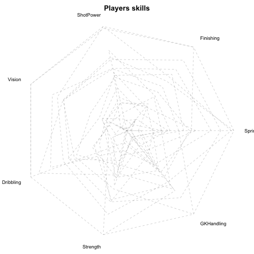

```r
#Creating star plot
require(grDevices)
stars(team_wise_mean[, 3:9], locations = c(0, 0), radius = FALSE, key.loc = c(0, 0), main = "Players skills", lty = 2)
```

It's worth to watch how rating and other skills are co-related for a player

```r
#Selecting ratings and few key skills for English league players
BPL_updated <- subset(BPL,,c(6,20,23,24,30,38,49,55))
```

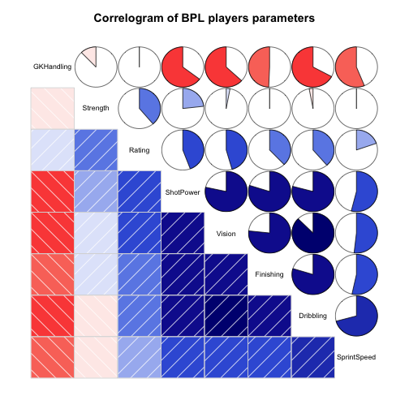

```r
#Creating correlogram for skills of English league players
library(corrgram)
corrgram(BPL_updated, order=TRUE, lower.panel=panel.shade,upper.panel=panel.pie, text.panel=panel.txt,main="Correlogram of BPL players parameters")
```

**Modeling**

Before ending my analysis, I would like to create two models - GLM to predict any new player ratings basis his skills value and clustering to form cluster of similiar type players

```r
#linear modeling
lm(Rating~GKHandling,gk)
```

```
##
## Call:
## lm(formula = Rating ~ GKHandling, data = gk)
##
## Coefficients:
## (Intercept)   GKHandling
##     11.6304       0.8432
```

```r
gkmodel <- lm(Rating~GKHandling,gk)
lm(Rating~GKHandling + GKDiving + GKReflexes,gk)
```

```
##
## Call:
## lm(formula = Rating ~ GKHandling + GKDiving + GKReflexes, data = gk)
##
## Coefficients:
## (Intercept)   GKHandling     GKDiving   GKReflexes
##     -0.4891       0.3925       0.2912       0.3118
```

```r
lm(Rating~GKHandling + GKDiving + I(GKReflexes^2),gk)
```

```
##
## Call:
## lm(formula = Rating ~ GKHandling + GKDiving + I(GKReflexes^2),
##     data = gk)
##
## Coefficients:
##     (Intercept)       GKHandling         GKDiving  I(GKReflexes^2)
##       10.079227         0.390715         0.287094         0.002347
```

```r
gkmodel2 <- lm(Rating~GKHandling + GKDiving + I(GKReflexes^2),gk)
gkmodel3 <- update(gkmodel2, ~.+GKPositioning,gk)
newgk <- data.frame(GKHandling = c(88,76,58))
newgk$predictions <- predict(gkmodel,newgk,interval = "prediction")
newgk
```

```
##   GKHandling predictions.fit predictions.lwr predictions.upr
## 1         88        85.82860        79.54329        92.11391
## 2         76        75.71067        69.44171        81.97963
## 3         58        60.53377        54.27077        66.79677
```

It's always an interesting task to unearth players which are similar to other top players. So following is the clustering model to cluster top strikers, midfielders, defenders and goalkeepers. By top, I mean the ones having overall rating of 80 and above

```r
#clustering
top <- f[which(f$Rating > 79),]

st <- top[top$position == "ST",]
st2 <- subset(st,,c(4,17:58))
stgrp <- hclust(dist(st2))
```

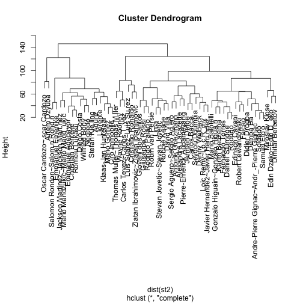

```r
plot(stgrp,labels = st2$SearchName)
```

```r
cb <- top[top$position == "CB",]
cb2 <- subset(cb,,c(4,17:58))
cbgrp <- hclust(dist(cb2))
```

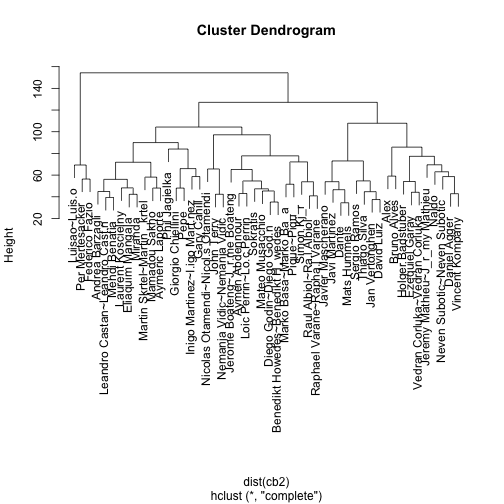

```r
plot(cbgrp,labels = cb2$SearchName)
```

```r
cm <- top[top$position == "CM",]
cm2 <- subset(cm,,c(4,17:58))
cmgrp <- hclust(dist(cm2))
```

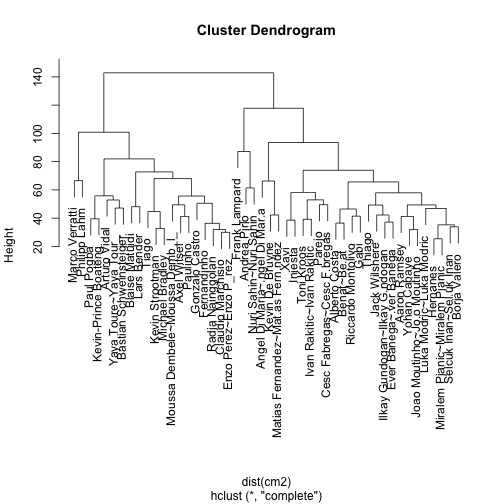

```r
plot(cmgrp,labels = cm2$SearchName)
```

```r
gk <- top[top$position == "GK",]
gk2 <- subset(gk,,c(4,17:58))
gkgrp <- hclust(dist(gk2))
```

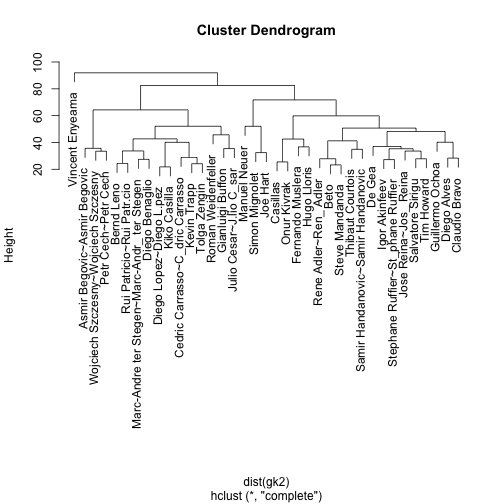

```r
plot(gkgrp,labels = gk2$SearchName)
```

**OPTIONAL: Did you create any models with your dataset? Discuss the strengths and limitations of your model**

Yes, I have created a linear model for Goalkeepers. Verifying the data for the same this model appears to be efficient. The use of this model can be extended to other positions as well. Such model forms the basis of predicting possible ratings of underdeveloped talent.

In addition, I've also created clustering of top players and judging the players' playing type and clusters, I guess decent job had been done

**Final Plots and Summary**

**Plot 1**

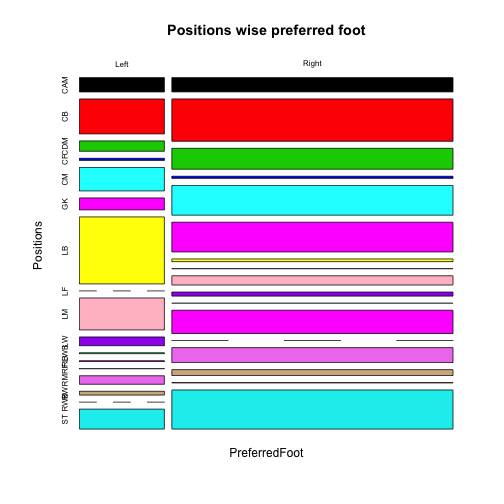

```r
#Position wise preferred foot
totals = table(fifa$PreferredFoot,fifa$position)

#creating custom palette
mypal <- c("black",   "red" ,    "green3" , "blue"   , "cyan"  ,  "magenta" ,"yellow"  ,"gray","pink", "purple", "springgreen", "magenta", "orange", "violet", "tan", "tomato", "cyan2", "thistle", "sienna", "plum4" )


#creating Mosaic plot
mosaicplot(totals,main="Positions wise preferred foot",xlab="PreferredFoot",ylab="Positions",color = mypal)
```

**Description 1**

This plot gives an interesting insight into players foot and their playing position. When forming a team (virtually or in reality), players foot become an important aspect as basis on which inside run, cross type, tackle etc. decided

**Plot 2**

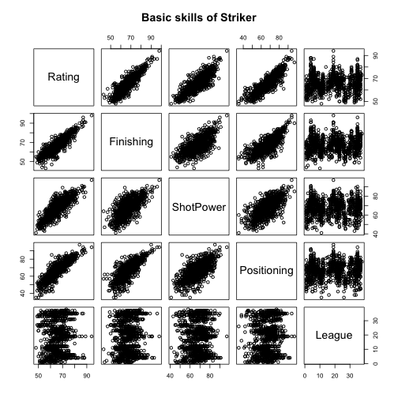

```r
#Relation between trikers skills
pairs(~Rating + Finishing + ShotPower + Positioning + League, data = striker, main = "Basic skills of Striker")
```

**Description 2**

This plot gives us a hint to look out for certain skills of striker in order to measure his ratings

**Plot 3**

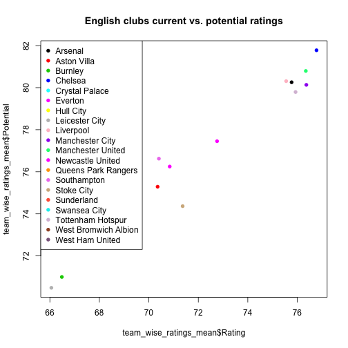

```r
#to understand current and potential ratings for England's clubs
englishclubs <- subset(BPL,,c(1,6,53))
team_wise_ratings_mean <- aggregate(.~Club.Name,data = englishclubs,mean)

#creating custom palette
mypal <- c("black",   "red" ,    "green3" , "blue"   , "cyan"  ,  "magenta" ,"yellow"  ,"gray","pink", "purple", "springgreen", "magenta", "orange", "violet", "tan", "tomato", "cyan2", "thistle", "sienna", "plum4" )

#creating scatterplot to understand current mean rating of a team and mean potential rating for English clubs
plot(team_wise_ratings_mean$Rating,team_wise_ratings_mean$Potential,pch =16, col = mypal,main = "English clubs current vs. potential ratings")
legend('topleft',paste(team_wise_ratings_mean$Club.Name),col=mypal,pch=16)
```

**Description 3**

This plot give us an insight into mean ratings of currently playing 20 teams in barclays premier league and their potential ratings. While selecting a team initially in the game, one can opt for team with higher potential rating thus having a brighter chances of better future players

**Reflection**

This dataset is of details about players in FIFA 15 game. I started by understanding the individual variables in the data set, and then I explored interesting questions and leads as I continued to make observations on plots.

Initially there were few challenges -

- Duplicate values
- Some NAs

Post data cleansing, it became an interesting task to analyse this data step by step

I started with complete data, followed by observing top 5 leagues, then exploring the data position wise and finaly sticking to one particular league - Barclays premier league

This top down approach helped me in better understanding the data

During this exploratory analysis, I created linear model and did clustering of players as well